# Human Activity Recognition - Weightlifting

#### *Practical Machine Learning assignment*

### Introduction

This document details a prediction methodology used to determine how well a test subject performed a particular set of weightlifting actions.

The Weight Lifting Exercise (WLE) dataset used is courtesy of the paper *“Qualitative Activity Recognition of Weight Lifting Exercises.” Proceedings of 4th International Conference in Cooperation with SIGCHI (Augmented Human ’13) . Stuttgart, Germany: ACM SIGCHI, 2013* authored by Velloso, E.; Bulling, A.; Gellersen, H.; Ugulino, W.; Fuks, H.

Analysis environment is Windows 7 64-bit / R ver 3.1.2.

### Data preparation

Load the libraries we’ll need:

```r
library(caret)
library(gbm)
```

Read the data:

```r
url <- "http://d396qusza40orc.cloudfront.net/predmachlearn/pml-training.csv"
download.file(url,"WLDtraining.csv")
url <-"http://d396qusza40orc.cloudfront.net/predmachlearn/pml-testing.csv"
download.file(url,"WLDtesting.csv")
WLDtraining<-read.csv("WLDtraining.csv")
WLDtesting<-read.csv("WLDtesting.csv")
```

Have an initial look at the training set:

```r
dim(WLDtraining)
```

```
## [1] 19622   160
```

```r
str(WLDtraining)
```

```r
WLDtraining<-WLDtraining[,-grep("_roll_",colnames(WLDtraining))]
WLDtraining<-WLDtraining[,-grep("_pitch_",colnames(WLDtraining))]
WLDtraining<-WLDtraining[,-grep("_yaw_",colnames(WLDtraining))]
dim(WLDtraining)
```

```
## [1] 19622    72
```

```r
str(WLDtraining)
```

```r
WLDtraining<-WLDtraining[,-grep("user_name",colnames(WLDtraining))]
WLDtraining<-WLDtraining[,-grep("_timestamp",colnames(WLDtraining))]
WLDtraining<-WLDtraining[,-grep("_window",colnames(WLDtraining))]
WLDtraining<-WLDtraining[,-1] # "X"
```

Checking for zero covariates, we find that fields with names starting with “kurtosis” are all near zero variance predictors, and should thus be eliminated from our training data:

```r
nearZeroVar(WLDtraining,saveMetrics=TRUE)
WLDtraining<-WLDtraining[,-grep("kurtosis_",colnames(WLDtraining))]
```

[output not shown]

We perform the same transformations on the test set:

```r
WLDtesting<-WLDtesting[,-grep("_roll_",colnames(WLDtesting))]
WLDtesting<-WLDtesting[,-grep("_pitch_",colnames(WLDtesting))]
WLDtesting<-WLDtesting[,-grep("_yaw_",colnames(WLDtesting))]
WLDtesting<-WLDtesting[,-grep("user_name",colnames(WLDtesting))]
WLDtesting<-WLDtesting[,-grep("_timestamp",colnames(WLDtesting))]
WLDtesting<-WLDtesting[,-grep("_window",colnames(WLDtesting))]
WLDtesting<-WLDtesting[,-1]
WLDtesting<-WLDtesting[,-grep("kurtosis_",colnames(WLDtesting))]
dim(WLDtesting)
```

```
## [1] 20 61
```

For cross-validation purposes, we now split our training set into 2 subsets - training and testing:

```r
inTrain <- createDataPartition(y=WLDtraining$classe,p=0.6,list=FALSE)
training<-WLDtraining[inTrain,]
testing<-WLDtraining[-inTrain,]
dim(training)
```

```
## [1] 11776    61
```

```r
dim(testing)
```

```
## [1] 7846   61
```

We still need to deal with the missing values in the data, and will do this by means of a preprocessing object:

```r
ppdata<-training[,1:60]
ppobj<-preProcess(ppdata,method="knnImpute")
training.imp<-predict(ppobj,ppdata)
```

Since we’ve now preprocessed our training set, we must apply the same preprocessing to our testing subset and original test set, using the object created with the training data:

```r
testing.imp<-predict(ppobj,testing[,1:60])
WLDtesting.imp<-predict(ppobj,WLDtesting[,1:60])
```

### Modelling

Our data is now prepared, and for the moment we’ll leave the test set strictly alone and only work with the training set. As random forest is both a highly accurate prediction model and the main one used on the original WLE data, we’ll apply a random forest model which includes a preprocessing command to normalise all the variables:

```r
modelrf<-train(training$classe~.,method='rf',data=training.imp,
               preProcess=c("center","scale"))
```

Let’s check the accuracy of this on our testing subset:

```r
predrf<-predict(modelrf,testing.imp)
round(confusionMatrix(testing$classe,predrf)$overall[1],2)
```

```
## Accuracy
##     0.99
```

99% accuracy is an excellent result. We’ll also try a gradient boosting model, and a linear discriminant analysis, to see whether they have a similar or even better fit:

```r
modelgbm<-train(training$classe~.,method="gbm",data=training.imp,
                preProcess=c("center","scale"),verbose=FALSE)
```

```r
modellda<-train(training$classe~.,method="lda",data=training.imp,
                preProcess=c("center","scale"))
```

```r
predgbm<-predict(modelgbm,testing.imp)
predlda<-predict(modellda,testing.imp)
round(confusionMatrix(testing$classe,predgbm)$overall[1],2)
```

```
## Accuracy
##     0.96
```

```r
round(confusionMatrix(testing$classe,predlda)$overall[1],2)
```

```
## Accuracy
##     0.71
```

It’s clear from our cross-validation that the random forest model is providing the best predictions, and as it seems unlikely that we’ll be able to improve on the achieved 99% accuracy without overfitting we won’t try for a better fit by applying different models or stacking them.

The plot of our final model showing the error rate:

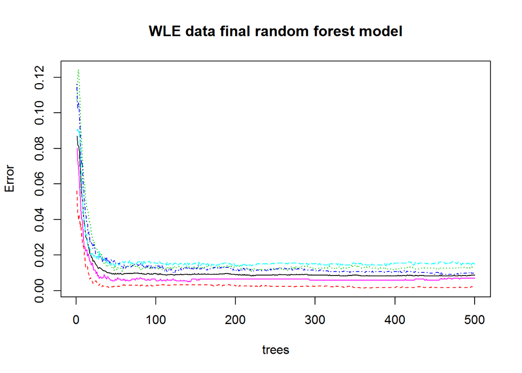

```r
plot(modelrf$finalModel,main="WLE data final random forest model")
```

### Conclusion

Using a random forest model with the missing data imputed using k nearest neighbour and the data normalised by centering and scaling, we predict, with 95% confidence, that we will achieve out of sample accuracy of 99%, giving us an out of sample error rate of 1%.